# Neural Networks

Intro to MLPs (Multilayer Perceptrons)

Author

[Your name here]

**TipMajor Tip**

Note: It is highly recommended to either…

1. Render this activity first to read/follow the instructions, but run the code on the qmd. To the right of the Render button, click the settings gear and select ‘Preview in Viewer Pane’ for the most ideal set up.
2. Or, complete the activity in Visual mode.

## Learning Objectives

Neural networks power image recognition, speech transcription, and large language models, but the core idea is surprisingly small. A neural net is a sequence of simple functions that are trained by repeatedly nudging their numbers in whichever direction that makes the loss or “error” shrink. This activity will help you understand that idea, and apply it to image classification. By the end of this guide you will hopefully be able to:

1. **Describe** what a dense Neural Network or Multilayer Perception (MLP) computes: layers, weights, and activation functions.
2. **Explain** how training works. *i.e. loss (“error”) function, gradient descent, backpropagation.*
3. **Train** a logistic regression and an MLP on an image dataset in R using the `torch` package, and compare them.
4. **Use** a train / validation / test split to tune a model.
5. Learn what other kinds of networks exist and which R tools you could use next.

## Cheatsheet

| Concept | Definition |
| --- | --- |
| Layer | linear map + bias, then a non-linear activation |
| Activation | the thing that makes depth useful (ReLU is the usual hidden-layer default) |
| Softmax + cross-entropy | turn scores into probabilities; punish low probability on the true class |
| Gradient descent | $\mathbf{W} \leftarrow \mathbf{W} - \eta\,\partial J/\partial \mathbf{W}$ |
| SGD / mini-batch | estimate the gradient on a small random batch |
| Backprop (`$backward()`) | chain rule, output → input, reusing work |
| Epoch | one full pass over the training data |
| Overfitting | train performance keeps improving, validation performance does not |
| Early stopping, L2 (`weight_decay`), dropout | three ways to rein in overfitting |
| Train / validation / test | fit weights / choose settings / report the final number once |
| Training loop | `zero_grad()`, forward, loss, `backward()`, `step()` |

## Part 0: Setup

We will use the [`torch`](https://torch.mlverse.org/) package, which gives R users the same engine that powers PyTorch, with no Python required. PyTorch is a widely used library for deep learning that was built for Python. We will also use `torchvision` for datasets and then, of course, tidyverse and ggplot for wrangling and plotting.

```r
# Run once and then comment out. You probably already have tidyverse and ggplot installed, so delete those if you'd like!
install.packages(c("torch", "torchvision", "tidyverse", "ggplot2"))
torch::install_torch() #if prompted, you may need to run this
```

```r
library(torch)
library(torchvision)
library(tidyverse)
library(ggplot2)

torch_is_installed()   # check to see if this is TRUE
torch_manual_seed(456)
set.seed(456)
```

**TipTip**

If `torch_is_installed()` does not return `TRUE`, you may need to run `torch::install_torch()` again and restart R.

## Part 1: Anatomy of a Neural Network

### Layers of simple functions

A neural network is composed of an input, a hidden layer, and an output. The hidden layer is composed of a collection of simple functions. Each layer in the hidden section will do two things:

1. A **linear step**: The linear step acts like a simple linear function y = Wx + b. W is the weight matrix, a collection of numbers used to scale transform or evaluate data (our input) across different fields. B is bias, similar to the y intercept of a standard linear equation. It is added to the weighted sum of inputs before passing through the next non-linear step.
2. A **non-linear step**: An *activation function* is applied to each output of the linear function, one at a time. The activation function decides how strong each node in a layer should fire, or pass a signal to the next layer.

For a network with two layers, the prediction is

$$\hat{\mathbf{y}} = g^{(2)}\!\Big(\mathbf{W}^{(2)}\, g^{(1)}\!\big(\mathbf{W}^{(1)}\mathbf{x} + \mathbf{b}^{(1)}\big) + \mathbf{b}^{(2)}\Big)$$

where $\mathbf{x}$ is the input, each $\mathbf{W}^{(l)}$ and $\mathbf{b}^{(l)}$ are the **weights and biases** the network will learn, and $g^{(l)}$ is the activation function. “Deep” learning just means more of these layers stacked up. In the image-recognition setting, early layers tend to pick up simple patterns (like edges) and later layers combine them into more abstract ones (like parts of objects). The math here isn’t super important, but it’s actually just stuff you already know!

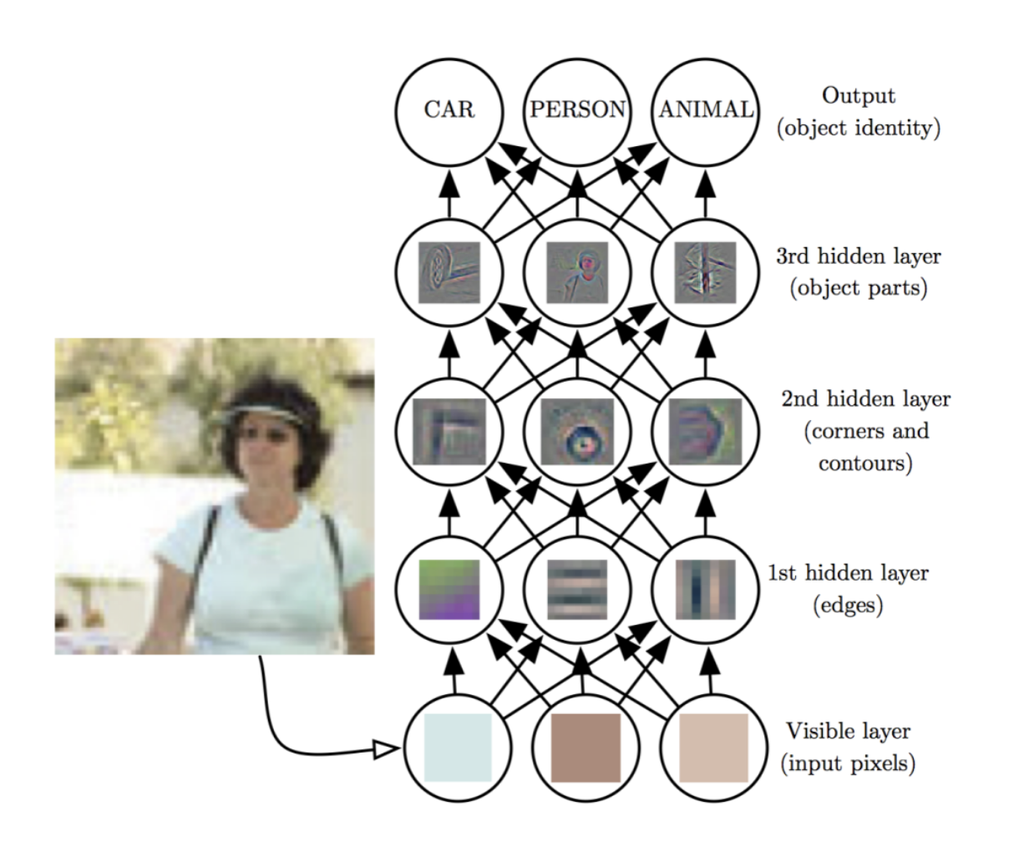

### Why we need activation functions

Without the activation function, the whole network would collapse into one big matrix multiplication, which is just a linear model, no matter how many layers you stacked. **Activation functions adds the non-linearity that lets the network approximate complicated functions.** There are three common activation functions:

Name

Formula

Notes

Sigmoid

$g(z) = \dfrac{1}{1+e^{-z}}$

ideal for binary classification, as it keeps output values between 0 and 1

Tanh

$g(z) = \dfrac{e^{z}-e^{-z}}{e^{z}+e^{-z}}$

maps any real number to a number between -1 and 1

ReLU

$g(z) = \max(0, z)$

the modern default for hidden layers

- If a number is *positive*, keep it
- If *negative* or *zero*, change it to zero

Again, the formulas aren’t important to remember, but it is nice to see!

### Task 1.1: Plot them

Run this! Which function has a flat region where the slope is nearly zero? (Hold that thought. It matters for training.)

```r
tibble(z = seq(-5, 5, by = 0.05)) |>
  mutate(sigmoid = 1 / (1 + exp(-z)),
         tanh    = tanh(z),
         relu    = pmax(0, z)) |>
  pivot_longer(-z, names_to = "activation", values_to = "g_z") |>
  ggplot(aes(z, g_z, colour = activation)) +
  geom_line(linewidth = 1) +
  labs(title = "Common activation functions", y = "g(z)") +
  theme_minimal()
```

#### What the final layer look like depends on what you are predicting:

- **Regression:** linear output ($g(z)=z$) with **squared loss** $\|\mathbf{y}-\hat{\mathbf{y}}\|^2$.
- **Classification into** $K$ classes:
  - A **softmax** turns the $K$ raw scores (called *logits*) into probabilities that sum to 1
  - **Cross-entropy loss** punishes the model for giving low probability to the true class (classic statistics/logistic regression):

$$\hat y_k = \frac{e^{z_k}}{\sum_{j=1}^{K} e^{z_j}}, \qquad
\mathcal{L}(\hat{\mathbf{y}}, y) = -\log \hat y_{y}$$

## Part 2: How a network learns

Training means finding the weights $\mathbf{W}$ and biases $\mathbf{b}$ that minimizes the loss between the real output and the desired output:

$$J(\mathbf{W}) = \frac{1}{N}\sum_{n=1}^{N} \mathcal{L}\big(\hat{\mathbf{y}}^{(n)}, \mathbf{y}^{(n)}\big)$$

This can be done with **gradient descent**:

1. Initializes the weights randomly.
2. Computing the gradient $\partial J / \partial \mathbf{W}$ determines which direction increases the loss (because calculus)
3. So we negate the gradient and it will go the opposite direction to decrease the loss: $\mathbf{W} \leftarrow \mathbf{W} - \eta\ \partial J / \partial \mathbf{W}$. n is the step size, also known as the learning rate. It informs how fast the function will converge to a minimum.
4. Then it repeats!

Two limitations:

- Real neural networks are super complex so finding the global minimum is often not possible, so we find the best we can.
- Computing the gradient for your total number of training examples will be expensive, so we can use **stochastic gradient descent (SGD)**. This estimates the gradient from a random **mini-batch** of examples at each step. Variants like **momentum** and **Adam** are optimization algorithms that can adapt the step size automatically.

### Backpropagation: reusing work

A network can have millions of parameters, so we cannot compute each partial derivative from scratch. **Backpropagation** uses the chain rule (calculus again!!) to move from the output back toward the input, *reusing* the work from later layers. The cost of computing all the gradients is about the same as one forward pass. That efficiency is why the “matrix multiply, then activation” structure became the standard.

### *(Optional Task 2.1)*

*You can try a backward pass by hand! If you know your linear algebra and calculus, go for it!*

Here is a tiny regression network: 2 inputs, 2 hidden units with ReLU, 1 linear output, squared loss, and biases fixed at 0 to keep the arithmetic friendly.

- Input $\mathbf{x} = (1, 2)$, Output $y = 1$
- $\mathbf{W}^{(1)} = \begin{pmatrix} 0.5 & -0.5 \\ 0.25 & 0.75 \end{pmatrix}$, $\quad \mathbf{W}^{(2)} = \begin{pmatrix} 1 & 2 \end{pmatrix}$

### *NOT Optional Task 2.2:* **Now let’s have `torch` do it**

If you did it by hand, you can compare.

```r
x  <- torch_tensor(c(1, 2))
y  <- torch_tensor(1)

W1 <- torch_tensor(matrix(c(0.5, -0.5,
                            0.25, 0.75), nrow = 2, byrow = TRUE),
                   requires_grad = TRUE)
W2 <- torch_tensor(matrix(c(1, 2), nrow = 1), requires_grad = TRUE)

h     <- torch_relu(W1$matmul(x))   # hidden layer
y_hat <- W2$matmul(h)               # linear output
loss  <- (y - y_hat)^2

loss$backward()                     # <- backpropagation

loss; y_hat
W2$grad
W1$grad
```

**TipCheck your hand calculation**

$\mathbf{z}^{(1)} = (-0.5,\ 1.75)$, so $\mathbf{h} = (0,\ 1.75)$. Then $\hat y = 3.5$ and the loss is $6.25$.

$\delta^{(2)} = -2(1-3.5) = 5$, so $\partial\mathcal{L}/\partial\mathbf{W}^{(2)} = (0,\ 8.75)$.

Pushing back: $\delta^{(2)}\mathbf{W}^{(2)} = (5, 10)$, and the ReLU derivative is $(0, 1)$ because the first pre-activation was negative. So $\delta^{(1)} = (0, 10)$ and

$$\partial\mathcal{L}/\partial\mathbf{W}^{(1)} = \begin{pmatrix} 0 & 0 \\ 10 & 20 \end{pmatrix}.$$

Notice the first hidden unit got **zero gradient**. It was “off” for this input, so its weights learn nothing from this example. Keep an eye out for this later: units that are off for *every* input are sometimes called dead units.

**ImportantCheckpoint**

You should be able to say, in your own words: *what does `loss$backward()` compute, and what would we do with those numbers next?* (Answer: the gradient of the loss with respect to every weight; we would subtract a small multiple of it from each weight.)

## Part 3: The Data

We will classify **MNIST**: 28 × 28 greyscale images of handwritten numbers. The same code will work on two other datasets with just one line changed.

**NotePick your dataset (personalization #1)**

`mnist_dataset` is a classic image classification dataset with handwritten numbers.

**`fashion_mnist_dataset`** has 10 types of clothing (shirts, sneakers, bags…).

**`kmnist_dataset`** has 10 handwritten Japanese Hiragana characters. Pick whichever sounds most fun and swap the function name in the chunk below. Everything after this works unchanged.

```r
ds_fun <- # TODO!          # try fashion_mnist_dataset, kmnist_dataset, or mnist_dataset

train_ds <- ds_fun("data", train = TRUE,  download = TRUE)
test_ds  <- ds_fun("data", train = FALSE, download = TRUE)

class_names <- train_ds$classes
```

The raw data is a big array of pixel intensities (0–255). Before modeling we do three things:

1. Rescale to $[-1, 1]$. Networks train better when inputs are on a standard scale (this is *input standardization*).
2. **Flatten** each 28 × 28 image into a vector of 784 numbers, since a hidden layer expects a vector as the input.
3. Split into **training**, **validation**, and **test** sets (more on why in a moment).

```r
prep_x <- function(arr) {
  t <- torch_tensor(as.array(arr))$to(dtype = torch_float()) / 255
  t <- (t - 0.5) / 0.5
  t$view(c(-1, 784))
}
prep_y <- function(labels) torch_tensor(as.integer(labels), dtype = torch_long())

x_all <- prep_x(train_ds$data);  y_all <- prep_y(train_ds$targets)
x_test <- prep_x(test_ds$data);  y_test <- prep_y(test_ds$targets)

# 50,000 train / 10,000 validation
train_idx <- sample(60000, 50000)
val_idx   <- setdiff(1:60000, train_idx)

x_train <- x_all[train_idx, ]; y_train <- y_all[train_idx]
x_val   <- x_all[val_idx, ];   y_val   <- y_all[val_idx]

x_train$shape   # 50000 784
```

**WarningR gotcha: labels start at 1**

R counts from 1, and so does `torch` for R. Class labels run **1–10**, not 0–9. For MNIST, the digit is `label - 1`. Rely on `class_names[label]` to translate.

Example: `0` is “class one” and `1` is “class two”

### Task 3.1: Explore your data

```r
data_long <- function(x, y, idx) {
  map_dfr(idx, function(i) {
    tibble(id    = i,
           label = class_names[as_array(y[i])],
           row   = rep(1:28, each = 28),
           col   = rep(1:28, times = 28),
           value = as_array(x[i, ]))
  })
}

data_long(x_train, y_train, sample(50000, 12)) |>
  mutate(panel = paste0("#", id, ": ", label)) |>
  ggplot(aes(col, row, fill = value)) +
  geom_raster() +
  scale_y_reverse() +
  scale_fill_gradient(low = "white", high = "black") +
  coord_equal() +
  facet_wrap(~ panel) +
  theme_void() +
  theme(legend.position = "none")
```

Which class do *you* think will be hardest to tell apart from another? Jot your guess down. We will check it at the end of Part 4.

## Part 4: Multi-class logistic regression baseline

Before building anything fancy, always train a simple baseline. A multi-class logistic regression is just a **neural network with no hidden layer**: one linear layer producing 10 scores, then softmax. This may look different than what you’re used to because we’re using `torch`.

```r
logreg <- nn_sequential(nn_linear(784, 10))
```

Because `nnf_cross_entropy()` applies the softmax internally, the model outputs raw **logits**, and we give them directly to the loss (Mathematically, this is numerically safer than computing probabilities and then taking logs yourself).

### The training loop

Every `torch` training loop has the same five beats. Fill in the three missing lines marked `YOUR CODE HERE`:

```r
evaluate <- function(model, x, y) {
  model$eval()
  with_no_grad({
    out <- model(x)
    tibble(loss = nnf_cross_entropy(out, y)$item(),
           acc  = (out$argmax(dim = 2) == y)$to(dtype = torch_float())$mean()$item())
  })
}

train_model <- function(model, x_tr, y_tr, x_va, y_va,
                        epochs = 5, lr = 1e-3, batch_size = 128,
                        optimizer = optim_adam, ...) {
  dl  <- dataloader(tensor_dataset(x_tr, y_tr),
                    batch_size = batch_size, shuffle = TRUE)
  opt <- optimizer(model$parameters, lr = lr, ...)
  history <- tibble()

  for (epoch in seq_len(epochs)) {
    model$train()
    coro::loop(for (batch in dl) {
      opt$zero_grad()                 # 1. reset old gradients
      out <- model(batch[[1]])        # 2. forward pass: logits for this mini-batch

      # YOUR CODE HERE: 3. compute the cross-entropy loss (out vs. batch[[2]])
      # YOUR CODE HERE: 4. backpropagate
      # YOUR CODE HERE: 5. take an optimizer step
    })

    tr <- evaluate(model, x_tr, y_tr)
    va <- evaluate(model, x_va, y_va)
    history <- bind_rows(history,
      tibble(epoch = epoch,
             train_loss = tr$loss, train_acc = tr$acc,
             val_loss   = va$loss, val_acc   = va$acc))
    cat(sprintf("epoch %2d | train loss %.3f | val loss %.3f | val acc %.3f\n",
                epoch, tr$loss, va$loss, va$acc))
  }
  history
}
```

**TipStuck? Peek at the three lines**

```r
loss <- nnf_cross_entropy(out, batch[[2]])
loss$backward()
opt$step()
```

Why `zero_grad()` first? `torch` *accumulates* gradients into `$grad` each time you call `backward()`, so you must clear the old ones every iteration.

Now train it! An **epoch** is one full pass, forward and backwards, through the training data. Choosing the number of epochs is an optimization problem in itself but five is a good start for this activity.

Once you run the code chunk below, you will see these following evaluation metrics:

- *train loss***:** Measures the error on the training dataset
- *val loss*: Measures the error on the validation dataset
- *val acc:* Measures how accurate the predictions are on the validation dataset

```r
torch_manual_seed(1)
logreg <- nn_sequential(nn_linear(784, 10))
hist_logreg <- train_model(logreg, x_train, y_train, x_val, y_val, epochs = 5)
```

### Task 4.1: What did the model learn?

A logistic regression has one weight per pixel per class, so we can literally *look at* what each class is searching for:

```r
W <- as_array(logreg[[1]]$weight)   # 10 x 784

map_dfr(1:10, function(k) {
  tibble(class = class_names[k],
         row   = rep(1:28, each = 28),
         col   = rep(1:28, times = 28),
         weight = W[k, ])
}) |>
  ggplot(aes(col, row, fill = weight)) +
  geom_raster() +
  scale_y_reverse() +
  scale_fill_gradient2(low = "firebrick", mid = "white", high = "steelblue") +
  coord_equal() +
  facet_wrap(~ class) +
  theme_void()
```

Blue pixels vote *for* a class and red pixels vote *against* it. Do you see the shapes? Then compute a quick confusion table on the validation set to check your Part 3 guess about which classes get mixed up:

```r
pred <- as_array(logreg(x_val)$argmax(dim = 2))
tibble(truth = class_names[as_array(y_val)], pred = class_names[pred]) |>
  count(truth, pred) |>
  ggplot(aes(pred, truth, fill = n)) +
  geom_tile() +
  scale_fill_viridis_c(trans = "sqrt") +
  theme_minimal() +
  theme(axis.text.x = element_text(angle = 45, hjust = 1))
```

**ImportantCheckpoint**

Write down your baseline’s final validation accuracy. For MNIST it is typically around 92%. **That number is what the MLP has to beat.**

## Part 5: Your first MLP!! (YAY)

Now add **hidden layers with ReLU activations**.

We will use 784 → 128 → 64 → 10. Do not worry too much about this sequence of numbers. It represents how we are compressing an image and rebuilding it based off of their most important characteristics:

```r
torch_manual_seed(1)
mlp <- nn_sequential(
  nn_linear(784, 128), nn_relu(),
  nn_linear(128, 64),  nn_relu(),
  nn_linear(64, 10)                 # logits; softmax lives inside the loss
)

mlp   # print the architecture

# How many learnable numbers? (logistic regression had 7,850)
sum(map_dbl(mlp$parameters, \(p) p$numel()))
```

That is 109,386 weights and biases, about 14 times more than the baseline. Because we wrote `train_model()` generically, training the MLP does not require **any new code**:

```r
hist_mlp <- train_model(mlp, x_train, y_train, x_val, y_val, epochs = 5)
```

### Task 5.1: Compare

Plot both models’ validation loss and accuracy on the same axes:

```r
bind_rows(logreg = hist_logreg, mlp = hist_mlp, .id = "model") |>
  pivot_longer(c(train_loss, val_loss, train_acc, val_acc),
               names_to = c("split", "metric"), names_sep = "_") |>
  ggplot(aes(epoch, value, colour = model, linetype = split)) +
  geom_line(linewidth = 1) +
  facet_wrap(~ metric, scales = "free_y") +
  theme_minimal()
```

Now let’s think!

- How much better is the MLP? Where do the training and validation curves start to **separate**? That gap is **overfitting**: the model is memorizing the training set rather than learning something general.
- The MLP has 14 times more parameters than the logistic regression. Was all that extra stuff worth it?

## Optional Advanced Challenge! (encouraged)

Now you are the researcher. Pick **one question** you are curious about, run **at least three variants**, and plot the results. Here is a reusable model builder, plus a few ideas.

```r
make_mlp <- function(hidden = c(128, 64), dropout = 0, batch_norm = FALSE,
                     n_in = 784, n_out = 10) {
  layers <- list(); prev <- n_in
  for (h in hidden) {
    layers <- c(layers, list(nn_linear(prev, h)))
    if (batch_norm) layers <- c(layers, list(nn_batch_norm1d(h)))
    layers <- c(layers, list(nn_relu()))
    if (dropout > 0) layers <- c(layers, list(nn_dropout(dropout)))
    prev <- h
  }
  do.call(nn_sequential, c(layers, list(nn_linear(prev, n_out))))
}
```

**NotePick your question (personalization #2)**

| If you’re curious about… | Try varying… |
| --- | --- |
| **Size:** is bigger always better? | `hidden = c(16)`, `c(128, 64)`, `c(512, 256, 128)` |
| **Learning rate:** how sensitive is training? | `lr = 1e-4, 1e-3, 1e-2, 1e-1` |
| **Optimizers:** does Adam really help? | `optimizer = optim_sgd` vs. `optim_sgd, momentum = 0.9` vs. `optim_adam` |
| **Regularization:** can we avoid the train/val gap or overfitting? | `dropout = 0, 0.2, 0.5`, or ridge regression via `weight_decay = 0, 1e-4, 1e-3` |
| **Data hunger:** how much data do we need? | train on only 500, 5,000, 50,000 images |
| **Datasets:** which is harder, digits, clothes, or Hiragana? | swap `ds_fun` in Part 3 and rerun |

**TipHelper definitions for your experiment**

- **Dropout** randomly zeroes a fraction of activations *during training only*. `train_model()` already calls `model$train()` / `model$eval()` for you, so evaluation uses the full network automatically.
- **Weight decay** is ridge regression. Pass it through `...`: `train_model(model, ..., weight_decay = 1e-3)`.
- **Optimizer with momentum:** `train_model(model, ..., optimizer = optim_sgd, lr = 0.05, momentum = 0.9)`.
- **Less data:** `train_model(model, x_train[1:500, ], y_train[1:500], x_val, y_val)`. Watch the train/val gap explode.

Here is a complete example changing the learning rate. Modify the code to answer *your* question:

```r
results <- map_dfr(c(1e-4, 1e-3, 1e-2, 1e-1), function(lr) {
  torch_manual_seed(1)
  model <- make_mlp()
  train_model(model, x_train, y_train, x_val, y_val, epochs = 5, lr = lr) |>
    mutate(setting = paste("lr =", lr))
})

ggplot(results, aes(epoch, val_acc, colour = setting)) +
  geom_line(linewidth = 1) +
  labs(title = "Validation accuracy by learning rate", y = "validation accuracy") +
  theme_minimal()
```

### Almost there!

Up until now, you have been choosing models by looking at the **validation** set. That is exactly what it is for. But after all that tuning, your validation score is slightly optimistic, because *you* picked the winner using it. The **test set** is the one you have not touched, and you get to use it **once**, at the very end:

```r
# Retrain your best configuration, then:
best_model <- make_mlp()   # <- put your winning settings here
train_model(best_model, x_train, y_train, x_val, y_val, epochs = 10)

evaluate(best_model, x_test, y_test)
```

**You are done with the challenge! You can fill in this sentence:**

> *“On [dataset], my best model was ______ (settings), which reached ____% validation accuracy and ____% test accuracy. Compared with the logistic regression baseline, the biggest lesson from my experiment was ______.”*

**ImportantWhy not just tune on the test set?**

If you repeatedly peek at the test set, your choices start to fit *its* quirks, and the reported accuracy no longer tells you how the model will do on genuinely new data.

Training set: fit the weights.

Validation set: choose hyperparameters.

Test set: report the final honest number.

## Part 6: Next steps & where you can go from here!

You built a **dense** network: every unit in one layer connects to every unit in the next. It treats the 784 pixels as an unordered bag of numbers. Different types of data will pair the best with different neural networks such as the following:

| Type of Data | Type of Neural Network | Key idea |
| --- | --- | --- |
| Images | Convolutional networks (CNNs) | reuse the same small filters across the whole image, exploiting spatial correlation |
| Text, audio, time series | Recurrent networks and **transformers** | handle sequences of variable length |
| Large-scale language and image generation | Large transformer models | the same training ideas (loss, gradients, backprop) at enormous scale |

The skills you have practiced today (a loss function, gradient descent, backpropagation, train/validation/test splits, regularization) will carry over to all of them.

**R toolbox for next steps:**

- [`torch`](https://torch.mlverse.org/): what you used today; supports CNNs, transformers, custom training loops.
- [`tidymodels`](https://www.tidymodels.org/): `mlp()` for small networks inside the workflow you already know.
- Free book: *Deep Learning and Scientific Computing with R torch* (Sigrid Keydana).

## References & Resoures

This guide synthesizes and adapts material from a neural networks course that Karyna took at Universidad Carlos III de Madrid:

- Lecture slides *Deep learning with Neural Networks* by Alejandro Lancho Serrano and Pablo Martínez Olmos, which themselves draw on MIT 6.S191: Introduction to Deep Learning (introtodeeplearning.com), *Deep Learning* by Goodfellow et al. (2017), and figures by Sebastian Raschka (sebastianraschka.com).
- Lab *Image classification with MLPs* by Pablo M. Olmos (Python/PyTorch), itself a wrap-up of Facebook’s Deep Learning course on Udacity. The structure of Parts 3–5 follows that lab, translated to R.
- `torch` for R: https://torch.mlverse.org/

# Reflection

Let us know how we did creating this activity! Reflect on your experience using some of the guiding questions below:

- **Where did you get stuck or confused and why? What did you do to overcome it?**
- **How well did you learn the activity’s learning objectives?**
- **Is there anything you wish you had learned?**